# Part I - (Ford GoBike System Data)

## Preliminary Wrangling

```python
# import all packages and set plots to be embedded inline
import numpy as np
import pandas as pd
import matplotlib.pyplot as plt
import seaborn as sb

%matplotlib inline

import warnings
warnings.filterwarnings('ignore')
```

```python
# Lodaing the dataset
df = pd.read_csv('201902-fordgobike-tripdata.csv')
```

```python
df.shape
```

```
(183412, 16)
```

```python
df.info()
```

```
<class 'pandas.core.frame.DataFrame'>
RangeIndex: 183412 entries, 0 to 183411
Data columns (total 16 columns):
 #   Column                   Non-Null Count   Dtype
---  ------                   --------------   -----
 0   duration_sec             183412 non-null  int64
 1   start_time               183412 non-null  object
 2   end_time                 183412 non-null  object
 3   start_station_id         183215 non-null  float64
 4   start_station_name       183215 non-null  object
 5   start_station_latitude   183412 non-null  float64
 6   start_station_longitude  183412 non-null  float64
 7   end_station_id           183215 non-null  float64
 8   end_station_name         183215 non-null  object
 9   end_station_latitude     183412 non-null  float64
 10  end_station_longitude    183412 non-null  float64
 11  bike_id                  183412 non-null  int64
 12  user_type                183412 non-null  object
 13  member_birth_year        175147 non-null  float64
 14  member_gender            175147 non-null  object
 15  bike_share_for_all_trip  183412 non-null  object
dtypes: float64(7), int64(2), object(7)
memory usage: 22.4+ MB
```

```python
# show the first five rows
df.head()
```

|  | duration_sec | start_time | end_time | start_station_id | start_station_name | start_station_latitude | start_station_longitude | end_station_id | end_station_name | end_station_latitude | end_station_longitude | bike_id | user_type | member_birth_year | member_gender | bike_share_for_all_trip |
| --- | --- | --- | --- | --- | --- | --- | --- | --- | --- | --- | --- | --- | --- | --- | --- | --- |
| 0 | 52185 | 2019-02-28 17:32:10.1450 | 2019-03-01 08:01:55.9750 | 21.0 | Montgomery St BART Station (Market St at 2nd St) | 37.789625 | -122.400811 | 13.0 | Commercial St at Montgomery St | 37.794231 | -122.402923 | 4902 | Customer | 1984.0 | Male | No |
| 1 | 42521 | 2019-02-28 18:53:21.7890 | 2019-03-01 06:42:03.0560 | 23.0 | The Embarcadero at Steuart St | 37.791464 | -122.391034 | 81.0 | Berry St at 4th St | 37.775880 | -122.393170 | 2535 | Customer | NaN | NaN | No |
| 2 | 61854 | 2019-02-28 12:13:13.2180 | 2019-03-01 05:24:08.1460 | 86.0 | Market St at Dolores St | 37.769305 | -122.426826 | 3.0 | Powell St BART Station (Market St at 4th St) | 37.786375 | -122.404904 | 5905 | Customer | 1972.0 | Male | No |
| 3 | 36490 | 2019-02-28 17:54:26.0100 | 2019-03-01 04:02:36.8420 | 375.0 | Grove St at Masonic Ave | 37.774836 | -122.446546 | 70.0 | Central Ave at Fell St | 37.773311 | -122.444293 | 6638 | Subscriber | 1989.0 | Other | No |
| 4 | 1585 | 2019-02-28 23:54:18.5490 | 2019-03-01 00:20:44.0740 | 7.0 | Frank H Ogawa Plaza | 37.804562 | -122.271738 | 222.0 | 10th Ave at E 15th St | 37.792714 | -122.248780 | 4898 | Subscriber | 1974.0 | Male | Yes |

```python
# converting the start and end time to datetime type
df[['start_time', 'end_time']] = df[['start_time', 'end_time']].astype('datetime64[ns]')

df.dtypes
```

```
duration_sec                        int64
start_time                 datetime64[ns]
end_time                   datetime64[ns]
start_station_id                  float64
start_station_name                 object
start_station_latitude            float64
start_station_longitude           float64
end_station_id                    float64
end_station_name                   object
end_station_latitude              float64
end_station_longitude             float64
bike_id                             int64
user_type                          object
member_birth_year                 float64
member_gender                      object
bike_share_for_all_trip            object
dtype: object
```

```python
# Extract day and hour from the start time of the ride
df['start_day'] = df['start_time'].dt.day_name()
df['start_hour'] = df['start_time'].dt.hour
```

```python
df.head(1)
```

|  | duration_sec | start_time | end_time | start_station_id | start_station_name | start_station_latitude | start_station_longitude | end_station_id | end_station_name | end_station_latitude | end_station_longitude | bike_id | user_type | member_birth_year | member_gender | bike_share_for_all_trip | start_day | start_hour |
| --- | --- | --- | --- | --- | --- | --- | --- | --- | --- | --- | --- | --- | --- | --- | --- | --- | --- | --- |
| 0 | 52185 | 2019-02-28 17:32:10.145 | 2019-03-01 08:01:55.975 | 21.0 | Montgomery St BART Station (Market St at 2nd St) | 37.789625 | -122.400811 | 13.0 | Commercial St at Montgomery St | 37.794231 | -122.402923 | 4902 | Customer | 1984.0 | Male | No | Thursday | 17 |

### What is the structure of your dataset?

> There are 183412 observation in the dataset with 16 different features most of them are numeric, and there are some of categorical features.

### What is/are the main feature(s) of interest in your dataset?

> I'm most interested in figuring out the duration of the rides, and the start time of the trips.

### What features in the dataset do you think will help support your investigation into your feature(s) of interest?

> I believe that the start_date will be a helpful feature because many information can be derived from this feature such as the hour, week , day, etc.

## Univariate Exploration

```python
np.log10(df['duration_sec'].describe())
```

```
count    5.263428
mean     2.860984
std      3.253917
min      1.785330
25%      2.511883
50%      2.710963
75%      2.900913
max      4.931682
Name: duration_sec, dtype: float64
```

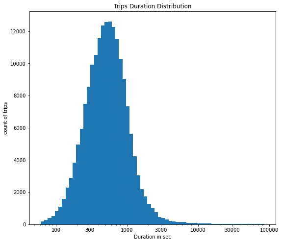

```python
plt.figure(figsize=(9,8))
bins = 10**np.arange(1.7853, 4.9317+0.05, 0.05)
plt.hist(data=df, x='duration_sec', bins=bins)
plt.xscale('log')
ticks = [100, 300, 1000, 3000, 10000, 30000, 100000]
plt.xticks(ticks, ticks)
plt.title('Trips Duration Distribution')
plt.xlabel('Duration in sec')
plt.ylabel('count of trips');
```

It looks like most of the trips have took around 300 Seconds to 1000 Seconds, and there are outliers in our disturabtion because some of the trips have took more than 30000 Seconds.

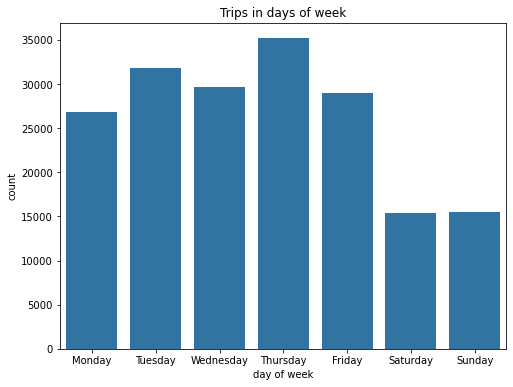

```python
plt.figure(figsize=(8,6))
base_color = sb.color_palette()[0]
days = ['Monday','Tuesday','Wednesday','Thursday','Friday', 'Saturday', 'Sunday']
sb.countplot(data=df, x='start_day', order=days, color=base_color)
plt.title('Trips in days of week')
plt.xlabel('day of week');
```

As it appear in the bar chart most rides were taken on Thursdays followed by Tuesdays, and the weekend have the lowest rides count.

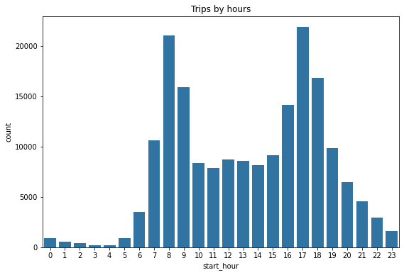

```python
plt.figure(figsize=(9,6))
sb.countplot(data=df, x='start_hour', color=base_color)
plt.title('Trips by hours');
```

The plot shows two peaks first at 8 a.m. and the second at 5 p.m. That could be predicted due to the start and the end of work of most people in these periods.

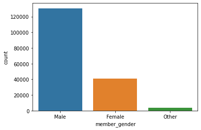

```python
g_order = df['member_gender'].value_counts().index
sb.countplot(df['member_gender'], order=g_order);
```

Most of the bikes users are males.

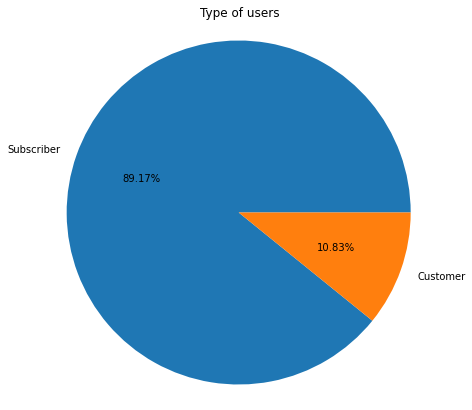

```python
plt.figure(figsize=(7,7))
labels = df['user_type'].value_counts().index
plt.pie(df['user_type'].value_counts(), labels=labels, autopct='%.2f%%');
plt.title('Type of users')
plt.axis('square');
```

Most of the users are subscribers (about 90%) and there is few of normal customers use the bikes.

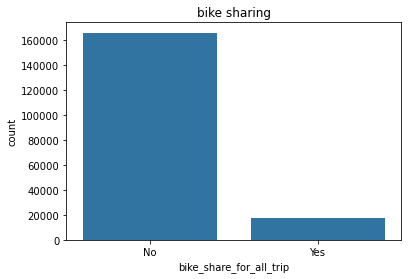

```python
sb.countplot(data=df, x='bike_share_for_all_trip', color=base_color);
plt.title('bike sharing');
```

### Discuss the distribution(s) of your variable(s) of interest. Were there any unusual points? Did you need to perform any transformations?

> The duration in seconds variable has a wide range of values with some outliers beyond the upper bound so I had to apply scale transformation on the axis to look like the unimodal, most users are males and most user type is subscriber.

### Of the features you investigated, were there any unusual distributions? Did you perform any operations on the data to tidy, adjust, or change the form of the data? If so, why did you do this?

> I have only done feature engineering on the start day variable and extracted the day of the week and start hour to use them in further investigations.

## Bivariate Exploration

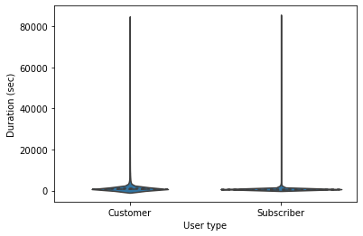

```python
sb.violinplot(data=df, x='user_type', y='duration_sec', color=base_color, inner='quartile')
plt.xlabel('User type')
plt.ylabel('Duration (sec)');
```

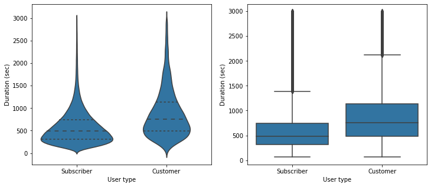

```python
# Set the limit of trips duration to 3000 second to remove the extreme values
filter_data = df.query('duration_sec < 3000')

plt.figure(figsize = [12, 5])

plt.subplot(1, 2, 1)
sb.violinplot(data=filter_data, x='user_type', y='duration_sec', color=base_color, inner='quartile')
plt.xlabel('User type')
plt.ylabel('Duration (sec)')

plt.subplot(1, 2, 2)
sb.boxplot(data=filter_data, x='user_type', y='duration_sec', color=base_color)
plt.xlabel('User type')
plt.ylabel('Duration (sec)');
```

As noticed subscribers took more trips with less duration, but customers have fewer trips than subscribers and tend to take more duration in their trips.

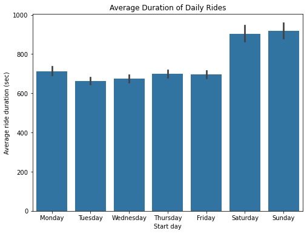

```python
plt.figure(figsize=(8,6))
sb.barplot(data=df, x='start_day', y='duration_sec', color=base_color, order=days)
plt.title('Average Duration of Daily Rides')
plt.xlabel('Start day')
plt.ylabel('Average ride duration (sec)');
```

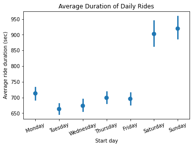

```python
sb.pointplot(data =df, x ='start_day', y ='duration_sec', color =base_color, linestyles ='', order=days)
plt.title('Average Duration of Daily Rides')
plt.xlabel('Start day')
plt.ylabel('Average ride duration (sec)')
plt.xticks(rotation=20);
```

The daily average ride duration decrease at the start of the week then it is dramatically increasing at the weekend, the reason for that could be that the users have more time on the weekend to practice sport on the bikes.

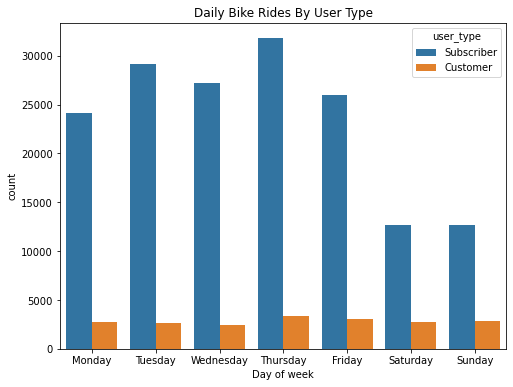

```python
# Number of bike rides per day per user type
plt.figure(figsize =(8, 6))
sb.countplot(data =df, x ='start_day', hue ='user_type', order=days, hue_order=['Subscriber', 'Customer'])
plt.xlabel('Day of week')
plt.title('Daily Bike Rides By User Type');
```

Most trips for both the subscriber and customers are on Thursday, Moreover subscribers took more trips on normal weekdays and fewer on the weekends, unlike the customer there trips didn't decrease during the weekends.

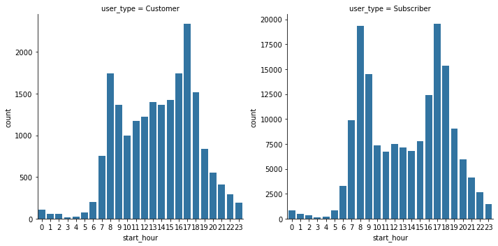

```python
g = sb.FacetGrid(data=df, col='user_type', size=5, sharey=False)
g.map(sb.countplot, 'start_hour');
```

Still in both types, the two peaks are at 8 a.m and 5 p.m, and for the subscribers, there is a relative decreasing in the period from 10 a.m to 3 p.m.

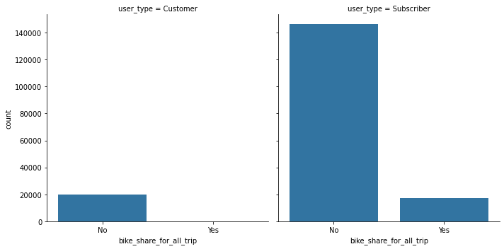

```python
g = sb.FacetGrid(data=df, col='user_type', size=5)
g.map(sb.countplot, 'bike_share_for_all_trip');
```

It is obvious the bike sharing option is available only for subscribers though there are majority of the subscribers are not share bikes.

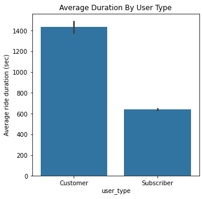

```python
plt.figure(figsize=(5,5))
sb.barplot(data=df, x='user_type', y='duration_sec', color=base_color)
plt.title('Average Duration By User Type')
plt.ylabel('Average ride duration (sec)');
```

As observed previously in the univariant plot Subscribers take more rides than Customers, but Customers obviously travel longer distances on average than Subscribers.

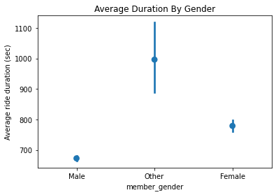

```python
sb.pointplot(data=df, x='member_gender', y='duration_sec', linestyles='')
plt.title('Average Duration By Gender')
plt.ylabel('Average ride duration (sec)');
```

As the point plot shows the females tend to travel longer distance than the males bike users.

### Talk about some of the relationships you observed in this part of the investigation. How did the feature(s) of interest vary with other features in the dataset?

> Although the customers have fewer trips in this dataset, but when comparing the duration of the trips to the subscribers they took more time on trips.

### Did you observe any interesting relationships between the other features (not the main feature(s) of interest)?

> Interestingly the relationship between gender and the duration of the trip, reflects that the females travel more distances than the males on average.

## Multivariate Exploration

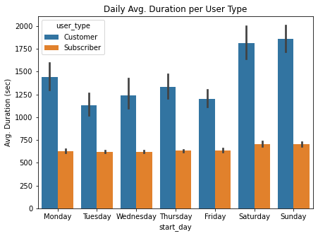

```python
plt.figure(figsize=(7,5))
sb.barplot(data=df, x='start_day', y='duration_sec', hue='user_type', order=days)
plt.title('Daily Avg. Duration per User Type')
plt.ylabel('Avg. Duration (sec)');
```

Customers tend to travel long distances during the day of the week especially on the weekends, whereas subscribers travel short distances about the same every day with a minor increase on the weekends.

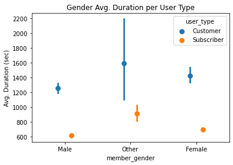

```python
sb.pointplot(data=df, x='member_gender', y='duration_sec', linestyles='', hue='user_type', dodge=0.2)
plt.title('Gender Avg. Duration per User Type')
plt.ylabel('Avg. Duration (sec)');
```

### Talk about some of the relationships you observed in this part of the investigation. Were there features that strengthened each other in terms of looking at your feature(s) of interest?

> I extended my investigation further more with the the duration and and gender and the user type, the plots shows that the Customers are took longer rides than Subscribers.

### Were there any interesting or surprising interactions between features?

> I have noticed that the females took longer distances than males no matter what the user type.

## Conclusions

- It looks like most of the trips have took around 300 Seconds to 1000 Seconds.
- Most rides were taken on Thursdays followed by Tuesdays, and the weekend have the lowest rides count.
- Most of the bikes users are males.
- Most of the users are subscribers (about 90%) and there is few of normal customers use the bikes.
- Subscribers took more trips with less duration, but customers have fewer trips than subscribers and tend to take more duration in their trips.
- The daily average ride duration decrease at the start of the week then it is dramatically increasing at the weekend.
- Bike sharing option is available only for subscribers though there are majority of the subscribers are not share bikes.
- Females took longer distances than males no matter what the user type.